# mainHW3

```python
pip install wordcloud
```

```python
#Import libraries
import json
import seaborn as sns
import numpy as np

import matplotlib.pyplot as plt
from matplotlib import font_manager as fm
from wordcloud import WordCloud
from io import BytesIO
import base64
import plotly.graph_objects as go
```

```python
#Load movies.json as Python dictionary
with open("Tvdata.json") as f:
  tv_data = json.load(f)
```

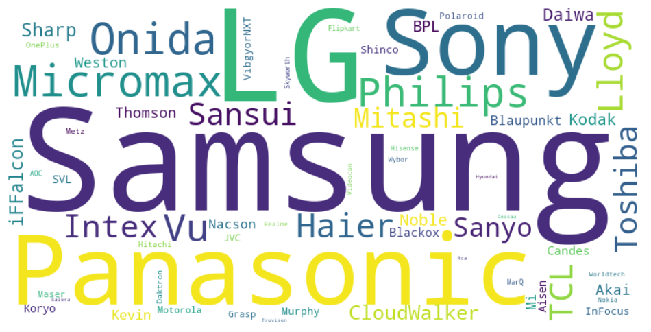

```python
brands = [item['Brand'] for item in tv_data]
wordcloud = WordCloud(width=800, height=400, background_color='white', colormap='viridis').generate(' '.join(brands))
plt.figure(figsize=(12,8))
plt.imshow(wordcloud, interpolation='bilinear')
plt.axis("off")
plt.show()
```

This code counts the number of occurrences of each unique TV brand and sorts the counts in descending order. Then it creates a histogram of the counts using a bar chart, where the x-axis represents the unique brands and the y-axis represents the count of each brand. Finally, it displays the histogram. The plt.subplots(figsize=(20,6)) command creates a figure with a size of 20 inches in width and 6 inches in height, while the plt.xticks(rotation=90) command rotates the x-axis labels by 90 degrees for better readability. The title, x-axis label, and y-axis label of the plot are also set using plt.title(), plt.xlabel(), and plt.ylabel() respectively.

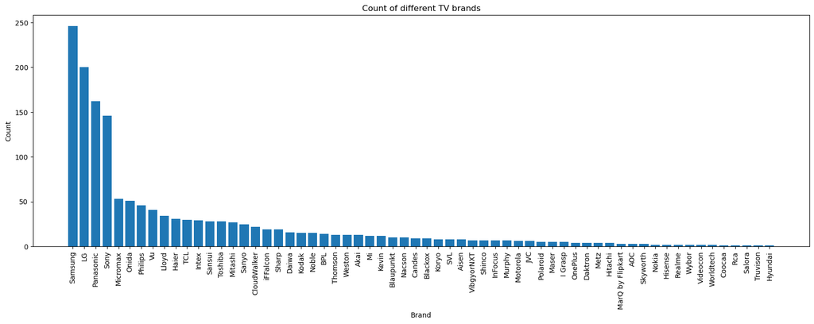

```python
# Count the number of occurrences of each unique TV brand
brand_counts = {}
for brand in types_tv:
    if brand in brand_counts:
        brand_counts[brand] += 1
    else:
        brand_counts[brand] = 1

# Sort the brand counts in descending order
sorted_counts = sorted(brand_counts.items(), key=lambda x: x[1], reverse=True)

# Create a histogram of the prices
fig, ax = plt.subplots(figsize=(20,6))
plt.xticks(rotation=90)
plt.bar([x[0] for x in sorted_counts], [x[1] for x in sorted_counts])
plt.title('Count of different TV brands')
plt.xlabel('Brand')
plt.ylabel('Count')
plt.show()
```

This code is analyzing the TV data and creating a bar chart of the average price for each TV brand.

First, it creates a dictionary brand_prices where the keys are the TV brands and the values are lists of their corresponding prices. It uses a loop to iterate over the tv_data list and extract the Brand and price_in_india attributes. It converts the price from a string to a float and adds it to the appropriate brand list in the dictionary.

Next, it creates a new dictionary brand_avg_prices where the keys are the TV brands and the values are the average prices of that brand, calculated using the numpy library np.mean function.

Then, it sorts the dictionary in descending order based on the average price using the sorted function and creates two new lists sorted_brands_names and sorted_brands_prices that contain the sorted brand names and prices.

Finally, it creates a bar chart using matplotlib with the brand names as the x-axis and the average prices as the y-axis. It sets the title, x-label, and y-label, and rotates the x-axis labels by 90 degrees for readability.

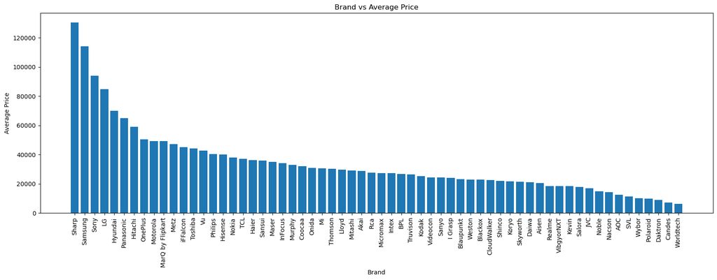

```python
brand_prices = {}
for item in tv_data:
    brand = item['Brand']
    price_str = item['price_in_india']
    price = float(price_str)  # convert to float

    if brand in brand_prices:
        brand_prices[brand].append(price)
    else:
        brand_prices[brand] = [price]

brand_avg_prices = {}
for brand, prices in brand_prices.items():
    avg_price = np.mean(prices)
    brand_avg_prices[brand] = avg_price

sorted_brands = sorted(brand_avg_prices.items(), key=lambda x: x[1], reverse=True)
sorted_brands_names = [x[0] for x in sorted_brands]
sorted_brands_prices = [x[1] for x in sorted_brands]

fig, ax = plt.subplots(figsize=(20,6))
ax.bar(sorted_brands_names, sorted_brands_prices)
ax.set_xlabel('Brand')
ax.set_ylabel('Average Price')
ax.set_title('Brand vs Average Price')
plt.xticks(rotation=90)
plt.show()
```

```python
import json

# Load the JSON data from file
with open("Tvdata.json") as f:
    tv_data = json.load(f)

# Print the brand of each TV
for obj in tv_data:
    print(obj['Brand'])

# Define a list of features to report on
features_to_report = [
    "Brand",
    "Model",
    "price_in_india",
    "display_size",
    "resolution_standard",
    "no_of_usb_port",
    "no_of_hdmi_port",
    "smart_tv",
    "built_in_wifi",
    "refresh_rate_hz",
    "launch_year"
]

# Calculate the average price of all TVs
total_price = sum(int(str(tv["price_in_india"]).strip()) for tv in tv_data)
average_price = total_price / len(tv_data)
# Generate the report
print("TV Data Report\n")
print(f"Total number of TVs: {len(tv_data)}")
print(f"Average price of TVs: Rs. {average_price:.2f}\n")

for feature in features_to_report:
    feature_values = set(tv[feature] for tv in tv_data)
    feature_values_str = ", ".join(str(value) for value in feature_values)
    print(f"{feature}: {feature_values_str}\n")

total_price = sum(int(str(tv["price_in_india"]).strip()) for tv in tv_data)
avg_price = total_price / len(tv_data)
```

[output not shown]

[output cut: 1490 more lines]

[output not shown]

```python
# Define an HTML template for displaying a single TV
tv_template = """
<div class="tv">
  <img src="{PictureURL}" alt="{Brand} {Model}">
  <h2>{Brand} {ProductName} {Model}</h2>
  <p><strong>Price:</strong> {price_in_india}</p>
  <p><strong>Display Size:</strong> {display_size} inch</p>
  <p><strong>Resolution:</strong> {resolution_standard} {resolution_pixels}</p>
  <p><strong>USB Ports:</strong> {no_of_usb_port}</p>
  <p><strong>HDMI Ports:</strong> {no_of_hdmi_port}</p>
  <p><strong>Smart TV:</strong> {smart_tv}</p>
  <p><strong>Weight:</strong> {weight_without_stand} kg</p>
  <p><strong>Refresh Rate:</strong> {refresh_rate_hz} Hz</p>
</div>
"""

# Generate HTML for individual TVs
tv_html = ""
for tv in tv_data:
    tv_html += tv_template.format(**tv)

# Define an HTML template for the report
report_template = """
<!DOCTYPE html>
<html>
<head>
  <title>TV Data Report</title>
  <style>
    .tv-container {{
      overflow: auto;
    }}
    .tv {{
      border: 1px solid black;
      padding: 20px;
      margin: 20px;
      float: left;
      width: 300px;
      height: 670px;
      text-align: center;
    }}
  </style>
</head>
<body>
  <h1>TV Data Report</h1>
  <p><strong>Total Price:</strong> ₹{total_price}</p>
  <p><strong>Average Price:</strong> ₹{avg_price:.2f}</p>
  <div class="tv-container">
    {tv_html}
  </div>
</body>
</html>
"""

# Generate HTML for the report
html = report_template.format(total_price=total_price, avg_price=avg_price, tv_html=tv_html)

# Write the HTML to a file
with open("tv_report5.html", "w") as f:
     f.write(html)
```

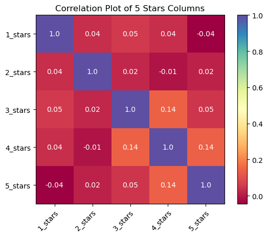

```python
col1 = [row['1_stars'] for row in tv_data]
col2 = [row['2_stars'] for row in tv_data]
col3 = [row['3_stars'] for row in tv_data]
col4 = [row['4_stars'] for row in tv_data]
col5 = [row['5_stars'] for row in tv_data]

# Create a 2D array with the column data
data_array = np.array([col1, col2, col3, col4, col5])

# Calculate the correlation matrix
corr_matrix = np.corrcoef(data_array)

# Create a heatmap using Matplotlib
fig, ax = plt.subplots()
im = ax.imshow(corr_matrix, cmap='Spectral')

# Add a color bar
cbar = ax.figure.colorbar(im, ax=ax)

# Set the x- and y-axis tick labels and the plot title
ax.set_xticks(np.arange(len(data_array)))
ax.set_yticks(np.arange(len(data_array)))
ax.set_xticklabels(['1_stars', '2_stars', '3_stars', '4_stars', '5_stars'])
ax.set_yticklabels(['1_stars', '2_stars', '3_stars', '4_stars', '5_stars'])
plt.title('Correlation Plot of 5 Stars Columns')

# Rotate the x-axis tick labels
plt.setp(ax.get_xticklabels(), rotation=45, ha='right', rotation_mode='anchor')

# Loop over data dimensions and add annotations
for i in range(len(data_array)):
    for j in range(len(data_array)):
        text = ax.text(j, i, round(corr_matrix[i, j], 2), ha='center', va='center', color='w')

# Display the plot
plt.show()
```

```python
# Sort the TVs by their average rating in descending order
sorted_tvs = sorted(tv_data, key=lambda x: ((x['5_stars'] + x['4_stars'])/(x['1_stars'] + x['2_stars'] + x['3_stars'] + x['4_stars'] + x['5_stars'])) if (x['1_stars'] + x['2_stars'] + x['3_stars'] + x['4_stars'] + x['5_stars']) != 0 else 0, reverse=True)

# Print the top ten TVs with score and number of reviews
for i, tv in enumerate(sorted_tvs[:10]):
    total_reviews = tv['1_stars'] + tv['2_stars'] + tv['3_stars'] + tv['4_stars'] + tv['5_stars']
    avg_rating = (tv['5_stars'] + tv['4_stars']) / total_reviews
    print(f"{i+1}. {tv['Brand']} {tv['ProductName']} {tv['model_name']} ({avg_rating:.2f} out of 5, based on {total_reviews} reviews)")
```

```
1. Sony Sony 43 Inches Ultra HD (4K) LCD TV (KD-43X8500C, Black) KD-43X8500C (1.00 out of 5, based on 100 reviews)
2. iFFalcon iFFalcon 65 Inches Ultra HD (4K) QLED Android Smart TV (65H71, Black) 65H71 (1.00 out of 5, based on 100 reviews)
3. VibgyorNXT Vibgyornxt 48 Inches Full HD LED Smart TV (48XXS) 48XXS (1.00 out of 5, based on 100 reviews)
4. Samsung Samsung 43 Inches Full HD LED TV (43J5100, Black) 43J5100 (1.00 out of 5, based on 100 reviews)
5. Micromax Micromax 32 Inches HD Ready LED TV (L32P8361HD, Black) L32P8361HD (1.00 out of 5, based on 100 reviews)
6. Nacson Nacson 24 Inches HD Ready LED TV (NS2616, Black) NS2616 (1.00 out of 5, based on 100 reviews)
7. Hisense Hisense 55 Inches Ultra HD (4K) LED Smart Android TV (55A73F, Black) Tornado 4K 55A73F (1.00 out of 5, based on 100 reviews)
8. Sony Sony 55 Inches Ultra HD (4K) LCD TV (KD-55X8200E, Black) KD-55X8200E (1.00 out of 5, based on 100 reviews)
9. Sony Sony 65 Inches Ultra HD (4K) LCD TV (KD-65X9300E, Black) KD-65X9300E (1.00 out of 5, based on 100 reviews)
10. Sony Sony 49 Inches Ultra HD (4K) LCD Smart TV (KD-49X7500E, Black) KD-49X7500E (1.00 out of 5, based on 100 reviews)
```

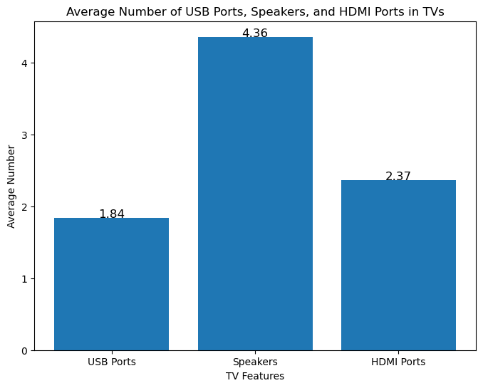

```python
# Create lists of feature values
usb_ports = [int(d['no_of_usb_port']) for d in tv_data]
speakers = [int(''.join(filter(str.isdigit, str(d['number_of_speakers'])))) for d in tv_data]
hdmi_ports = [int(d['no_of_hdmi_port']) for d in tv_data]

# Create bar plot
plt.figure(figsize=(8, 6))
plt.bar(['USB Ports', 'Speakers', 'HDMI Ports'], [sum(usb_ports)/len(usb_ports), sum(speakers)/len(speakers), sum(hdmi_ports)/len(hdmi_ports)])
plt.title('Average Number of USB Ports, Speakers, and HDMI Ports in TVs')
plt.ylabel('Average Number')
plt.xlabel('TV Features')
plt.text(0, sum(usb_ports)/len(usb_ports), f"{sum(usb_ports)/len(usb_ports):.2f}", ha='center', fontsize=12)
plt.text(1, sum(speakers)/len(speakers), f"{sum(speakers)/len(speakers):.2f}", ha='center', fontsize=12)
plt.text(2, sum(hdmi_ports)/len(hdmi_ports), f"{sum(hdmi_ports)/len(hdmi_ports):.2f}", ha='center', fontsize=12)

plt.show()
```

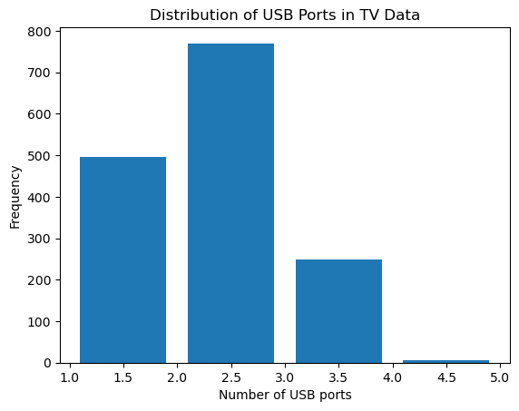

```python
# Extract the number of USB ports for each TV
usb_ports = [tv['no_of_usb_port'] for tv in tv_data]

# Create a histogram of the number of USB ports
plt.hist(usb_ports, bins=range(min(usb_ports), max(usb_ports) + 2, 1), rwidth=0.8)
plt.xlabel('Number of USB ports')
plt.ylabel('Frequency')
plt.title('Distribution of USB Ports in TV Data')
plt.show()
```

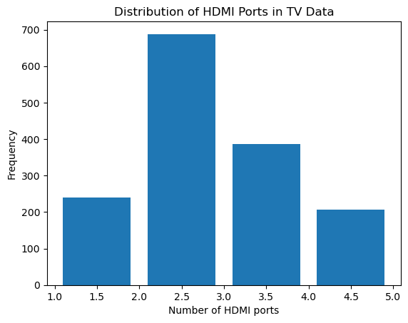

```python
# Extract the number of HDMI ports for each TV and convert to integers
hdmi_ports = [int(tv['no_of_hdmi_port']) for tv in tv_data]

# Create a histogram of the number of HDMI ports
plt.hist(hdmi_ports, bins=range(min(hdmi_ports), max(hdmi_ports) + 2, 1), rwidth=0.8)
plt.xlabel('Number of HDMI ports')
plt.ylabel('Frequency')
plt.title('Distribution of HDMI Ports in TV Data')
plt.show()
```

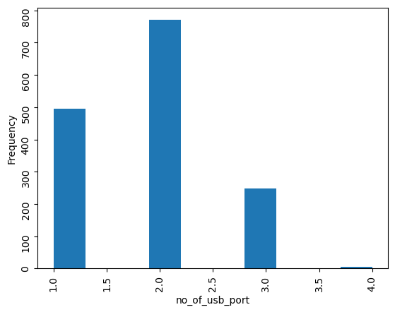

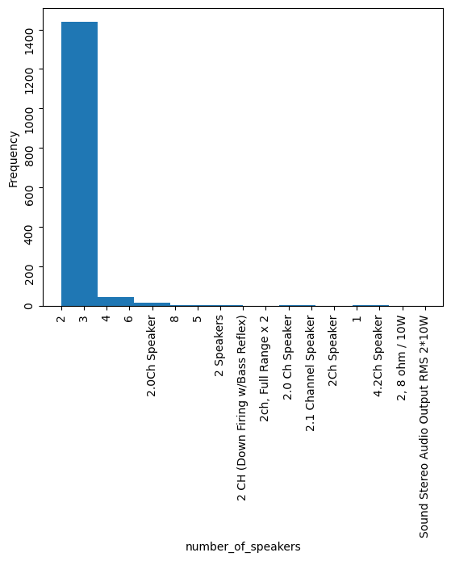

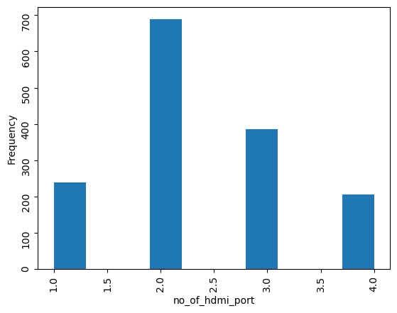

```python
# Define the attributes to plot
attributes = [ 'no_of_usb_port', 'number_of_speakers','no_of_hdmi_port']

# Create a string with HTML code for the plots
html_output = ''

for attr in attributes:
    # Get the data for the attribute
    data = [tv[attr] for tv in tv_data]

    # Create a histogram of the data
    fig, ax = plt.subplots()
    ax.hist(data, bins=10)

    # Add the size and x-axis label in vertical orientation
    ax.tick_params(axis='both', labelrotation=90)
    ax.set_xlabel(attr)
    ax.set_ylabel('Frequency')

    # Save the plot as a PNG image
    img_data = BytesIO()
    fig.savefig(img_data, format='png')
    img_data.seek(0)
    img_base64 = base64.b64encode(img_data.getvalue()).decode()

    # Add the plot to the HTML output
    html_output += f'<h2>{attr}</h2>'
    html_output += f'<img src="data:…"/>'

# Create a string with HTML code for the whole page
html_page = f'<html><head><title>TV Data</title></head><body>{html_output}</body></html>'

# Save the HTML page to a file
with open('tv_dataplot.html', 'w') as f:
    f.write(html_page)
```

# Recommendation

## Insights recomadation

1) The findings I recommended to my stackholders on which my main stackholders are customers to this are the top 10 tvs in the Indian markets and also this tv get ranked by there rating.

    2) The all attribte reports recommends or shows that the range of and filters of the all the attributes so in which customer easy check and see that how many brands I have, howmany models on website, howmany products, price range, hdmi ports, speakers, resolusion how many hz, lunch year of tv this recommendation helps customers knows about tv.  
    3) The insight shows of that the the brand vs count of the TV is easy shows that the **samsung** tv brand have much model and varients also shows the nearest 250 product is available. So, the code recommended that samsung is the first among all of the different options.  
    4) Findings from relation between brand vs price shows that high price of the tv of the above 1,10,000 rupees and lowest price near 5000 rupees. So on that plot customer can easily choose brand and can understands which brand's how many segment is avalible.  
    5) I created the the html page in which I recommended that the report of the all the data television all the specification so the customer can see which shows are available, means choices of tv shows watch and price to Purchase the products as per the choice.  
    6) Then I recommended the customer that the choice of their tv on how many hdmiports,Speakers,and usb ports in tvs because this nowadays which is much more booming and needed Featurs.